# Homework 2 - Coker

## Flights at ABIA

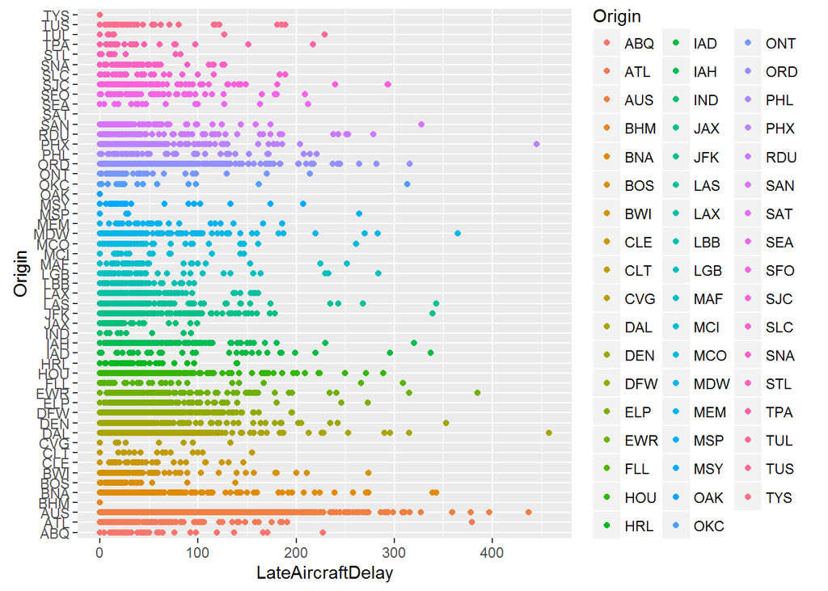

This figure plots the Late Aircraft Delay against the Origin, color coded based on the origin. Certain airports have very low instances of delay such as TYS, SAT, OAK, MSP, and BHM. Whereas other airpots have much higher instances of delay including ORD, MDW, IAH, JFK, IAH, HOU, DFW, DEN, and DAL.

## Practice with association rule mining

```
## Apriori
##
## Parameter specification:
##  confidence minval smax arem  aval originalSupport support minlen maxlen
##         0.3    0.1    1 none FALSE            TRUE   0.001      1      4
##  target   ext
##   rules FALSE
##
## Algorithmic control:
##  filter tree heap memopt load sort verbose
##     0.1 TRUE TRUE  FALSE TRUE    2    TRUE
##
## Absolute minimum support count: 15
##
## set item appearances ...[0 item(s)] done [0.00s].
## set transactions ...[655 item(s), 15296 transaction(s)] done [0.02s].
## sorting and recoding items ... [422 item(s)] done [0.00s].
## creating transaction tree ... done [0.00s].
## checking subsets of size 1 2 3 4 done [0.00s].
## writing ... [1049 rule(s)] done [0.00s].
## creating S4 object  ... done [0.00s].
```

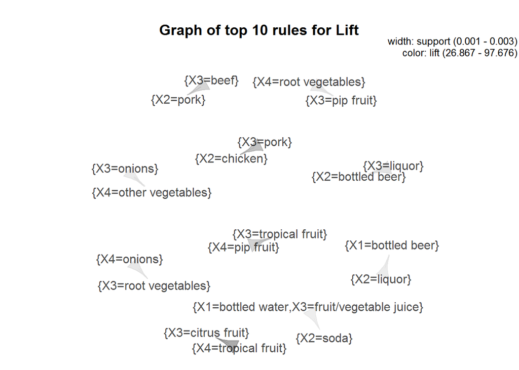

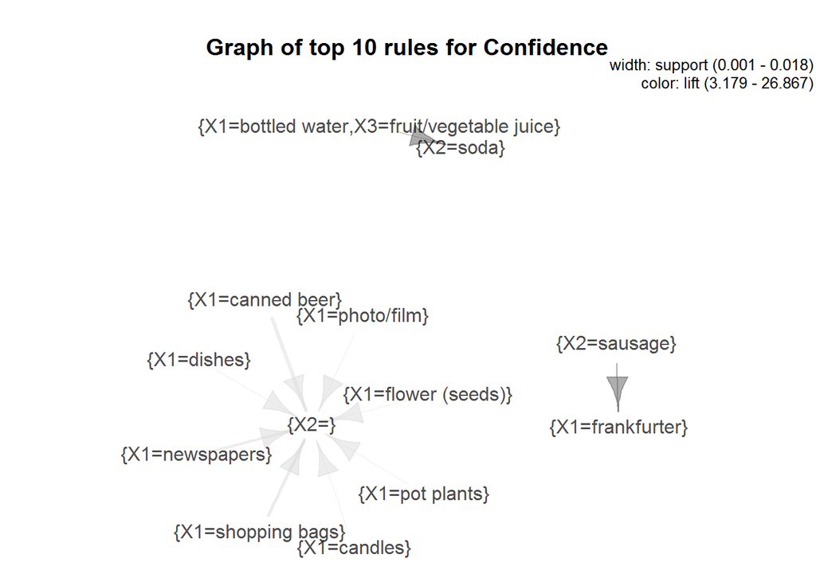

Support for the association wule mining is set to 0.001, which was chosen to allow for a high number of transactions. When support is set at a much higher fraction, the number of transactions that it specifies becomes very low.

Confidence is set at 0.3, which was chosen again to allow for a high number of patterns to be exposed for inspection.

The two graphs above show the top 10 rules for lift and confidence.

The top rules for lift show a strong association with meats (e.g. pork and chicken, beef and pork), and produces (e.g. onions and root vegetables, tropical fruit and citrus fruit, onions and other vegetables).

The top rules for confidence ashows an asociation with sausage and frankfurter as well as water with juices and soda. There were also a large number of items associated with no other items (newpapers, seeds, plants, shopping bags, film, dishes, and candles).